# Correlation

PS50008A Week 15 | Lecture

Gordon Wright

11 February 2026

## Learning Outcomes

By the end of this lecture you will be able to:

- Describe relationships between continuous variables
- Create and interpret scatterplots
- Calculate and interpret Pearson’s r and Spearman’s rho
- Explain why correlation does not imply causation

# Relationships Between Variables

## Beyond Group Differences

- So far: comparing groups (t-tests)
- Now: examining relationships between variables
- Both variables are measured, not manipulated

**Question:** Is there a relationship between study hours and exam scores?

## What is Correlation?

**Correlation**: A statistical measure that quantifies the strength and direction of the linear relationship between two continuous variables.

## Direction of Relationships

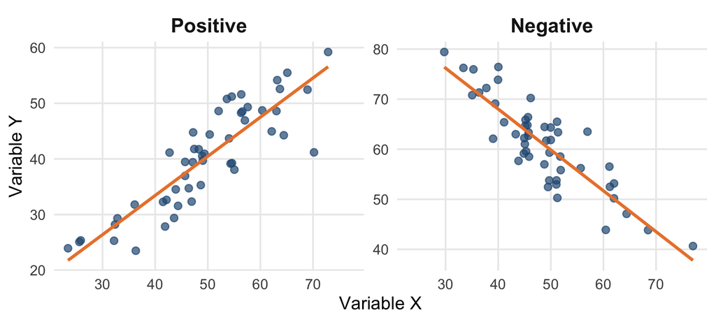

**Positive**: As X ↑, Y ↑

*Example: Height and weight*

**Negative**: As X ↑, Y ↓

*Example: Stress and sleep quality*

## Strength of Relationships

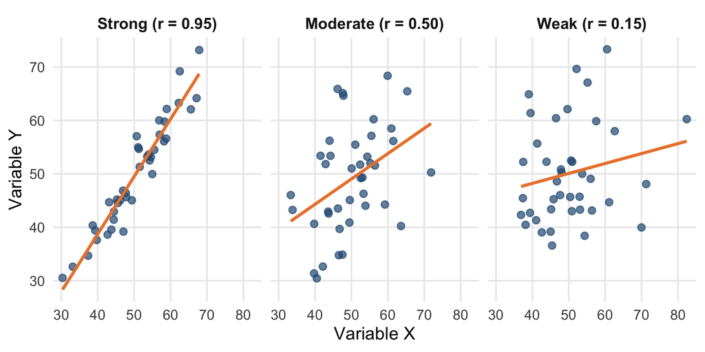

## Types of Relationships

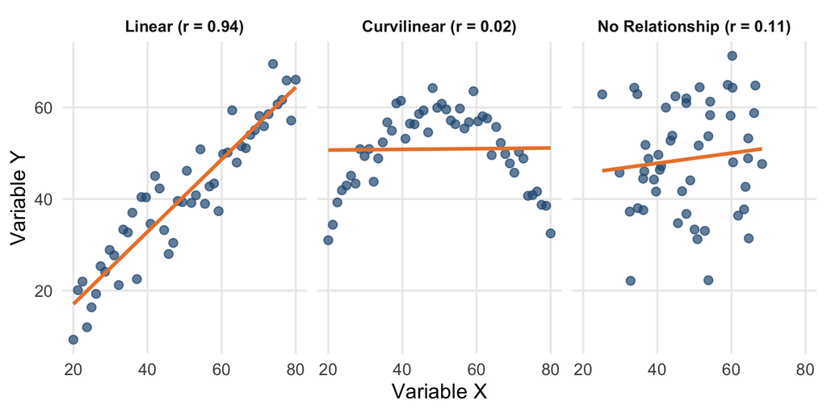

**Warning**

Correlation measures LINEAR relationships only. The curvilinear data has a strong pattern but r ≈ 0!

# Scatterplots

## Visualising Relationships

**Scatterplot**: A graph displaying the relationship between two continuous variables, with each observation represented as a point.

- X-axis: One variable (often predictor)
- Y-axis: Other variable (often outcome)
- Each point: One observation

## Creating Good Scatterplots

- Label axes clearly (with units)
- Use appropriate scales
- Include a trend line (with caution)
- Look for patterns, outliers, clusters

## Example: Study Hours vs Exam Scores

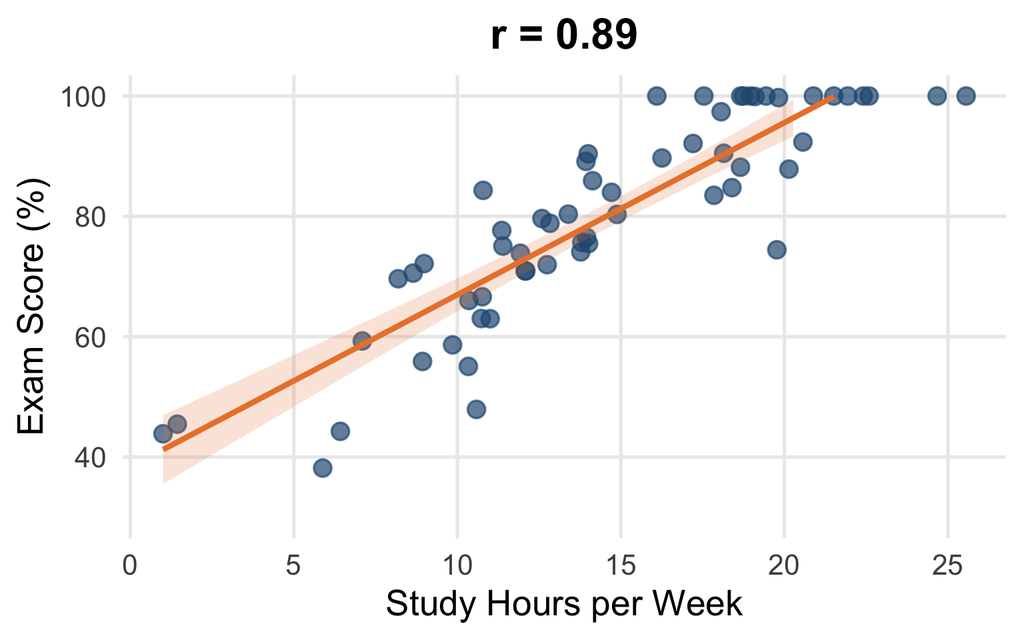

## What to Look For

**When examining a scatterplot, ask:**

1. Is there a relationship? (or random scatter?)
2. What direction? (positive/negative)
3. How strong? (tight/loose clustering)
4. Is it linear? (or curved?)
5. Any outliers? (unusual points)

## The Impact of Outliers

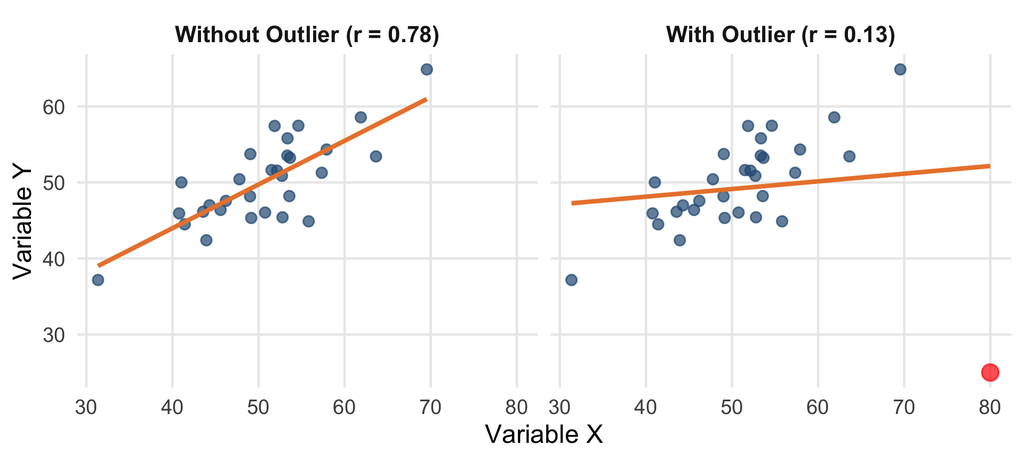

# Pearson’s r and Spearman’s rho

## Pearson’s Correlation Coefficient

**Pearson’s r**: A measure of the linear relationship between two continuous variables. Ranges from -1 to +1.

$$r = \frac{\sum(X - \bar{X})(Y - \bar{Y})}{(n-1)s_X s_Y}$$

## Interpreting Pearson’s r

| r value | Interpretation |
| --- | --- |
| +/- 1.0 | Perfect correlation |
| +/- 0.7 to 0.9 | Strong |
| +/- 0.4 to 0.6 | Moderate |
| +/- 0.1 to 0.3 | Weak |
| 0 | No linear relationship |

**Note**

These are rough guidelines. Context and field norms matter!

## Coefficient of Determination (r^2)

**r^2 (r-squared)**: The proportion of variance in Y that is explained by X. Found by squaring r.

If r = 0.6, then r^2 = 0.36

“36% of the variance in exam scores is explained by study hours.”

## Assumptions of Pearson’s r

- Both variables are continuous
- Linear relationship (check scatterplot!)
- Bivariate normality (roughly)
- No extreme outliers
- Independence of observations

## When Pearson’s r Fails

**Warning**

Pearson’s r is inappropriate when:

- Data are ordinal (ranked)
- Relationship is non-linear
- There are extreme outliers
- Data are severely non-normal

## Spearman’s Rho (rho)

**Spearman’s rho**: A non-parametric correlation based on ranks rather than raw values. More robust to outliers and non-linearity.

- Converts data to ranks
- Then calculates Pearson’s r on ranks
- Ranges from -1 to +1 (same interpretation)

## Pearson vs Spearman

**Use Pearson’s r when:**

- Both variables continuous
- Linear relationship
- Roughly normal data
- No major outliers

**Use Spearman’s rho when:**

- Ordinal data
- Non-linear but monotonic
- Non-normal data
- Outliers present

## Testing Significance

**Null hypothesis:** r = 0 (no correlation in population)

**Test:** Is our observed r significantly different from 0?

**Report:** r(df) = value, p = value

# Correlation Does Not Equal Causation

## The Third Variable Problem

**Third Variable (Confound)**: An unmeasured variable that causes both X and Y, creating a spurious correlation between them.

**Ice cream sales and drowning deaths are correlated.**

Third variable: Hot weather causes both!

## Directionality Problem

- Correlation shows X and Y are related
- But which causes which?
- X -> Y?
- Y -> X?
- Or both directions?

**Depression and social isolation are correlated.**

Does depression cause isolation, or isolation cause depression, or both?

## Famous Spurious Correlations

**Real correlations that aren’t causal:**

- Number of pirates and global temperature (r = -0.9)
- Nicolas Cage films and pool drownings (r = 0.87)
- Cheese consumption and death by bedsheet (r = 0.95)

tylervigen.com/spurious-correlations

## When CAN We Infer Causation?

- **Temporal precedence**: Cause before effect
- **Covariation**: They vary together
- **Elimination of alternatives**: No confounds

**Tip**

Experimental designs (with random assignment) can establish causation. Correlational designs cannot.

## Reporting Correlations

**APA format:**

“There was a strong positive correlation between study hours and exam scores, r(48) = .72, p < .001. Study time explained 52% of the variance in exam performance.”

# Summary

## Key Takeaways

- **Correlation** measures strength and direction of linear relationships
- **Scatterplots** visualise relationships - always look first!
- **Pearson’s r** for continuous, linear, normal data
- **Spearman’s rho** for ordinal, non-linear, or non-normal data
- **Correlation NEVER proves causation** (third variables, directionality)

## Next Week

**Reading Week** (16-20 February) — then Week 16: APA Report Writing & Research Project

## Questions?

Questions?

See you in the lab!